# Day 4: One-Way ANOVA and pairwise significant testing

## 1. Setup

```r
# core
library(dplyr)
library(ggplot2)
library(readr)
library(tidyr)
library(stringr)
# inference helpers
library(car)        # Levene's test
library(emmeans)    # estimated marginal means & Tukey
```

### 1.1 Load data

```r
##Import dataset
# Read the combined dataset (ensure the CSV file is in your working directory)
dat <- read.csv("MultiFactor_data.csv")
```

## 2. Create the analysis subset (control + single-factor treatments)

In the dataset:

- a column giving **number of factors applied** (given as `Lv`), where 0 = control, 1 = single-factor;
- a column giving **treatment identity** for single-factor rows (given as `remark`).

```r
treatments <- unique(dat$remark)[1:13] # extract control + single-factor treatments labels
single <- dat %>%
  filter(remark %in% treatments)         # control and single-factor only

# Choose responses of interest (edit as needed)
responses <- c("Decom") # soil pH, water-stable aggregates, decomposition rate etc.

summary(select(single, all_of(responses)))
```

```
##      Decom
##  Min.   :0.5882
##  1st Qu.:0.6425
##  Median :0.6592
##  Mean   :0.6608
##  3rd Qu.:0.6781
##  Max.   :0.7570
##  NA's   :2
```

## 3. Exploratory plots

### 3.1 Boxplots by treatment

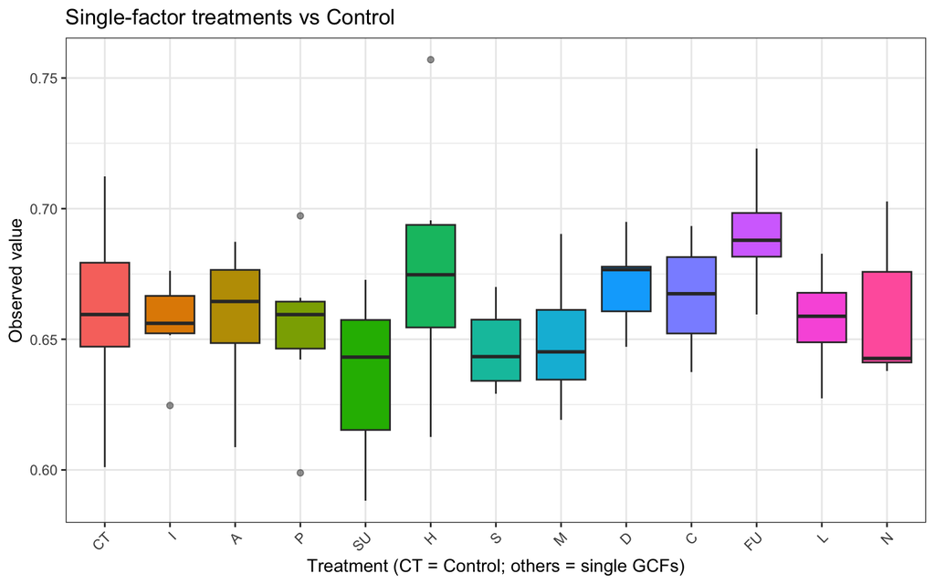

```r
single_long <- single %>%
  pivot_longer(all_of(responses), names_to = "Response", values_to = "Value")%>%
  mutate(remark = factor(remark, levels = treatments))

ggplot(single_long, aes(remark, Value, fill = remark)) +
  geom_boxplot(outlier.alpha = 0.5) +
  labs(title = "Single-factor treatments vs Control",
       x = "Treatment (CT = Control; others = single GCFs)",
       y = "Observed value") +
  theme_bw() + theme(legend.position = "none",
                     axis.text.x = element_text(angle = 45, hjust = 1))
```

> **Tip**: Look for visibly different medians/spreads across treatments. Mark imbalanced replication or potential outliers.

## 4. One-way ANOVA for one response

### 4.1 Compute One-way ANOVA

We’ll demonstrate for soil pH; repeat the same steps for WSA and Soil Decomposition rate.

[output not shown]

### 4.2 Multiple pairwise-comparison between the means of groups

In one-way ANOVA test, a significant p-value indicates that some of the group means are different, but we don’t know which pairs of groups are different.

It’s possible to perform multiple pairwise-comparison, to determin if the mean difference between specific pairs of group are statistically significant.

#### Tukey multiple pairwise-comparisons

As the ANOVA test is significant, we can compute **Tukey HSD** (Tukey Honest Significant Differences, R function: `TukeyHSD()`) for performing multiple pairwise-comparison between the means of groups.

The function `TukeyHD()` takes the fitted ANOVA as an argument.

[output not shown]

We have calculated adjusted p-values for all pairwise-groups. Given our research question, we’ll mainly focus on the comparisons of control treatment and single factor treatments (e.g., `D-CT`)

#### Pairwise t-test

The function `pairewise.t.test()` can be also used to calculate pairwise comparisons between group levels with corrections for multiple testing.

[output not shown]

> The result is a table of p-values for the pairwise comparisons. Here, the p-values have been adjusted by the Benjamini-Hochberg method.

## 5. Check ANOVA assumptions: test validity

The ANOVA test assumes that, the data are normally distributed and the variance across groups are homogeneous. We can check that with some diagnostic plots.

### 5.1 Check the homogeneity of variance assumption

The **residuals versus fit plot** can be used to check the homogeneity of variances.

[output not shown]

### 5.2 Check the normality assumption

**Normality plot of residuals**. In the plot below, the quantiles of the residuals are plotted against the quantiles of the normal distribution. A 45-degree reference line is also plotted.

The normal probability plot of residuals is used to check the assumption that the residuals are normally distributed. It should approximately follow a straight line.

[output not shown]

[output not shown]

### 5.3 Non-parametric alternative to one-way ANOVA test

a non-parametric alternative to one-way ANOVA is **Kruskal-Wallis rank sum test**, which can be used when ANNOVA assumptions are not met:

```
kruskal.test(PH ~ remark, data = single)
```